# Class 3

Colin Kuehl

September 10, 2026

This week we’ll start by illustrating some probability concepts in R and then continue building R skills by looking at the gapminder dataset

# Part 1: Probability

```
 ## R code to demonstrate probability distributions. You won't need to use this code later so don't worry if you are unclear what is going on.
```

Brief illustration of the law the large numbers

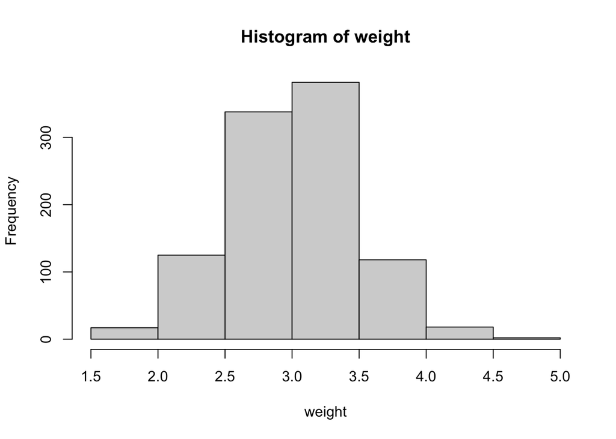

```r
#Don't worry about the code here. This is just an illustration.
n<-c(1:1000) #creates a vector of 1 to 100
weight<-rnorm(1000,3,.5) #Create a vector of length 100, with a mean of 3, and sd of .5
hist(weight)#quick histogram of what we just created
```

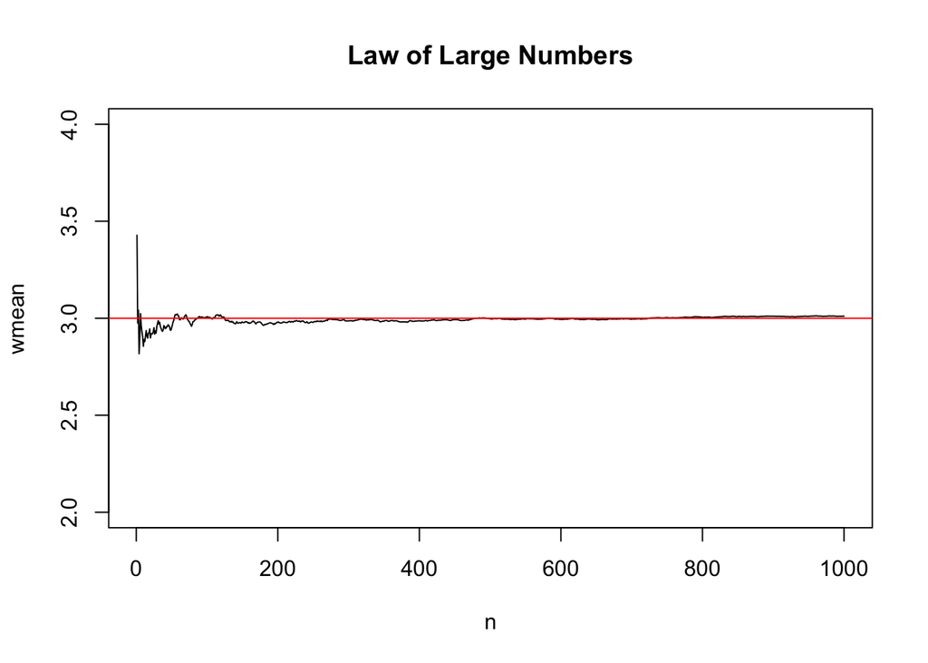

```r
s<-cumsum(weight) #cumulative sum
wmean <- s/n #finds mean at each point
plot(wmean,xlab="n",ylim=c(2,4),type="l",main="Law of Large Numbers")
abline(h=3, col="red")#horizontal line at the mean
```

```r
#what happens if we change to a thousand
```

## simulate die rolls

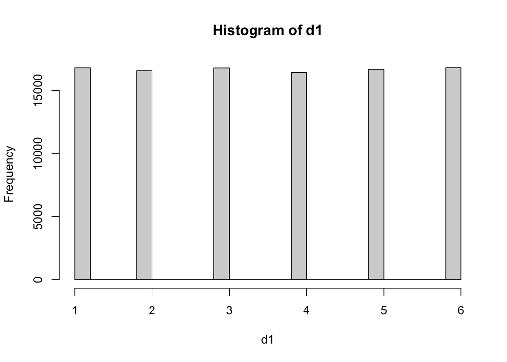

```r
d1 <- sample(1:6, 100000, prob=rep(1/6, 6), replace=TRUE)
  d2 <- sample(1:6, 100000, prob=rep(1/6, 6), replace=TRUE)

  hist(d1)#Expected uniform distribution for a singe die
```

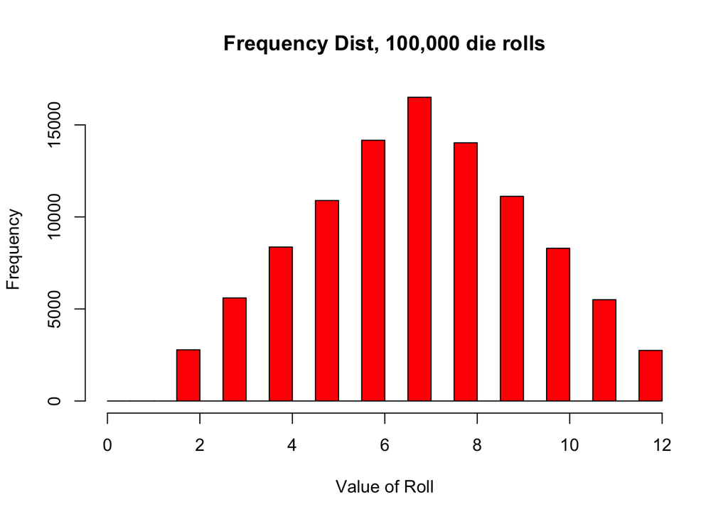

```r
die.roll <- d1 + d2 #sum of 2 dice

hist(die.roll, breaks= seq(0, 12, by=.5), prob=FALSE, col="red", main="Frequency Dist, 100,000 die rolls", xlab = "Value of Roll", ylab="Frequency")
```

```r
summary(die.roll)
```

```
##    Min. 1st Qu.  Median    Mean 3rd Qu.    Max.
##   2.000   5.000   7.000   6.996   9.000  12.000
```

```r
table(die.roll)
```

```
## die.roll
##     2     3     4     5     6     7     8     9    10    11    12
##  2780  5598  8366 10893 14166 16503 14028 11120  8297  5503  2746
```

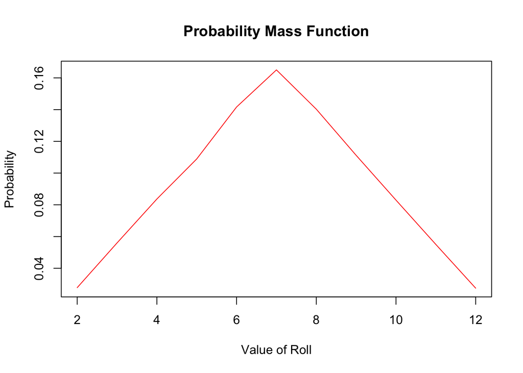

```r
  ## plot PMF

  freq<-cbind(table(die.roll))

  prval<-freq/100000
                                                  roll<-cbind(2,3,4,5,6,7,8,9,10,11,12)

plot(roll, prval, col="red", main="Probability Mass Function", xlab = "Value of Roll", ylab="Probability", pch=19, type="l")
```

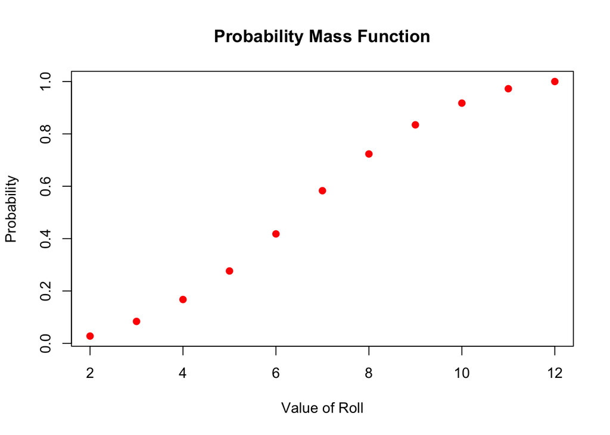

```r
## plot CDF
  #CDF = cumulative distribution function - probability that X will take a value less than or equal to X
cprval <- cumsum(prval)

 plot(roll, cprval, col="red", main="Probability Mass Function", xlab = "Value of Roll",  ylab="Probability", pch=19)
```

Creating different distributions

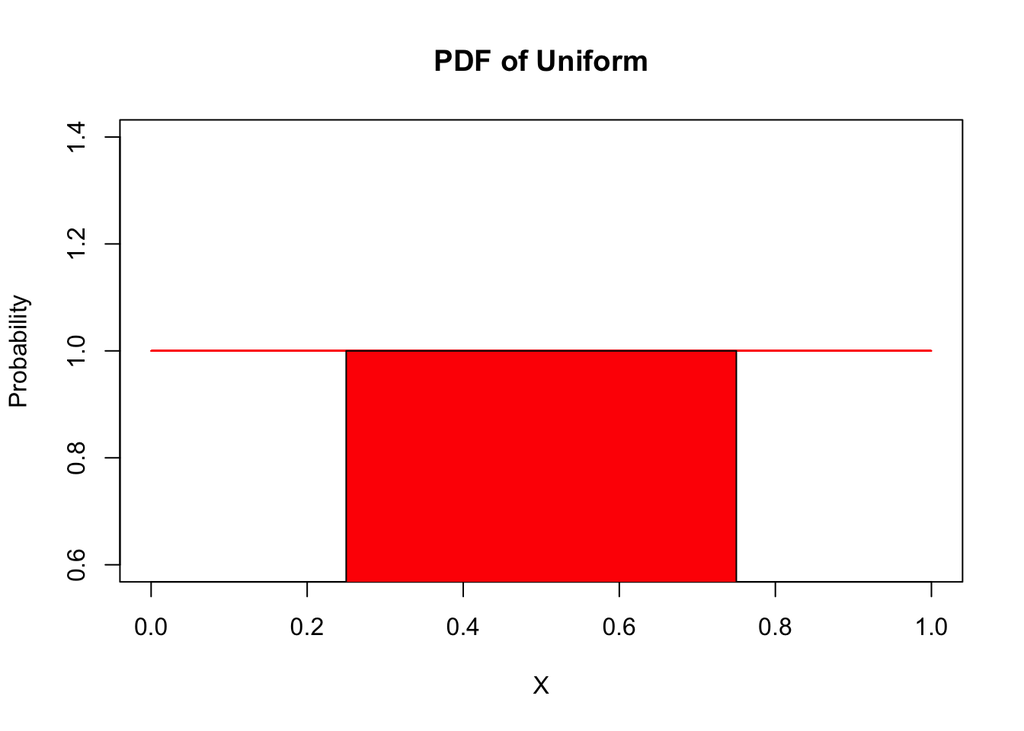

```r
## The uniform distribution

x <- runif(10000)
plot(x, x/x, type="l", col="red", main="PDF of Uniform", xlab = "X", ylab="Probability")

lb <- 0.25
ub <- 0.75
polygon(c(lb,lb,ub,ub), c(0,1,1,0), col="red")
```

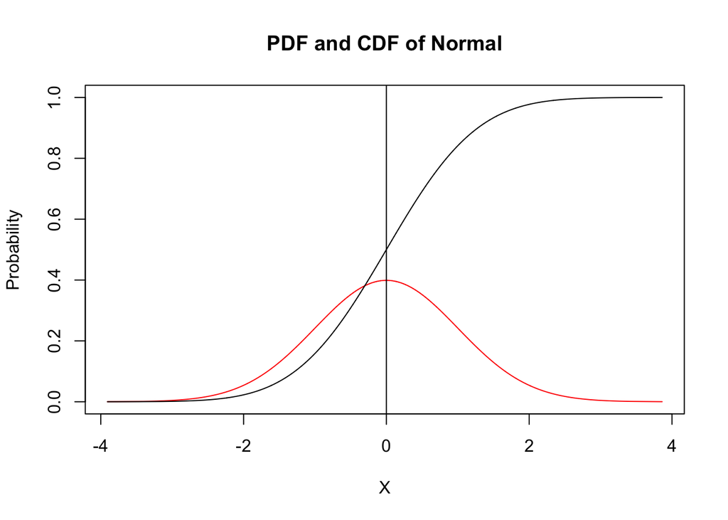

```r
 ## The normal distribution
 x <- sort(rnorm(10000))

plot(x, dnorm(x), type="l", col="red", main="PDF and CDF of Normal", xlab = "X",  ylab="Probability", ylim=c(0,1))
lines(x, pnorm(x))
abline(v=0)
```

#Packages

This week we’ll use some packages. Packages are mini pieces of software(sets of commands) that are loaded on top of base R. There are thousands to choose from and are very helpful for doing more specialized types of analysis.

I recommend loading all the packages you need at the beginning of your code (along with setting your working directory and loading your data).

The install command downloads the package to your computer. Once installed you don’t need to reinstall every time. (in fact, sometimes its better not to in case of differences between versions)

Two of the most commonly used are dplyr and ggplot

The library command unpacks(makes available) the package. Like taking it out off the shelf.

```r
#install.packages("tidyverse") ## This package is used to tidydata. We'll use it later
#install.packages("ggplot2") #Very popular graphing package

library(tidyverse)
library(ggplot2)

#I use these two packages almost every R session
```

Today we’ll explore the gapminder data. It contains life expectancy, population, and GDP per capita for countries every five years from 1952 to 2007. The gapminder data comes from the Gapminder Foundation: https://www.gapminder.org/data/ made famous by Hans Rosling’s TED talks. We’ll continue our exploration using R to understand and visualize data.

## Part 1: Getting to Know Gapminder

Make sure you have opened the Rproject first.

Today’s data comes packaged inside R itself. Instead of loading a file, we install a package once, then load it with library() each session.

Packages are like bonus material for R. We will use them all the time. Installing puts it on your computer. Library opens it(like a book) so everytime you use it you need library in your code first.

```r
#install.packages("gapminder") #only run this once ever - then put the # back in front
library(gapminder)
data("gapminder") #Puts into our environment
```

Looking over the data using commmands from yesterday

(hint: use code from yesterday)

```r
head(gapminder)
```

```
## # A tibble: 6 × 6
##   country     continent  year lifeExp      pop gdpPercap
##   <fct>       <fct>     <int>   <dbl>    <int>     <dbl>
## 1 Afghanistan Asia       1952    28.8  8425333      779.
## 2 Afghanistan Asia       1957    30.3  9240934      821.
## 3 Afghanistan Asia       1962    32.0 10267083      853.
## 4 Afghanistan Asia       1967    34.0 11537966      836.
## 5 Afghanistan Asia       1972    36.1 13079460      740.
## 6 Afghanistan Asia       1977    38.4 14880372      786.
```

```r
tail(gapminder)
```

```
## # A tibble: 6 × 6
##   country  continent  year lifeExp      pop gdpPercap
##   <fct>    <fct>     <int>   <dbl>    <int>     <dbl>
## 1 Zimbabwe Africa     1982    60.4  7636524      789.
## 2 Zimbabwe Africa     1987    62.4  9216418      706.
## 3 Zimbabwe Africa     1992    60.4 10704340      693.
## 4 Zimbabwe Africa     1997    46.8 11404948      792.
## 5 Zimbabwe Africa     2002    40.0 11926563      672.
## 6 Zimbabwe Africa     2007    43.5 12311143      470.
```

```r
summary(gapminder)
```

```
##         country        continent        year         lifeExp
##  Afghanistan:  12   Africa  :624   Min.   :1952   Min.   :23.60
##  Albania    :  12   Americas:300   1st Qu.:1966   1st Qu.:48.20
##  Algeria    :  12   Asia    :396   Median :1980   Median :60.71
##  Angola     :  12   Europe  :360   Mean   :1980   Mean   :59.47
##  Argentina  :  12   Oceania : 24   3rd Qu.:1993   3rd Qu.:70.85
##  Australia  :  12                  Max.   :2007   Max.   :82.60
##  (Other)    :1632
##       pop              gdpPercap
##  Min.   :6.001e+04   Min.   :   241.2
##  1st Qu.:2.794e+06   1st Qu.:  1202.1
##  Median :7.024e+06   Median :  3531.8
##  Mean   :2.960e+07   Mean   :  7215.3
##  3rd Qu.:1.959e+07   3rd Qu.:  9325.5
##  Max.   :1.319e+09   Max.   :113523.1
##
```

```r
dim(gapminder) #Count of how many observations and variables
```

```
## [1] 1704    6
```

```r
str(gapminder) #This tells us what kind of data R thinks each variable is - we'll talk about this later
```

```
## tibble [1,704 × 6] (S3: tbl_df/tbl/data.frame)
##  $ country  : Factor w/ 142 levels "Afghanistan",..: 1 1 1 1 1 1 1 1 1 1 ...
##  $ continent: Factor w/ 5 levels "Africa","Americas",..: 3 3 3 3 3 3 3 3 3 3 ...
##  $ year     : int [1:1704] 1952 1957 1962 1967 1972 1977 1982 1987 1992 1997 ...
##  $ lifeExp  : num [1:1704] 28.8 30.3 32 34 36.1 ...
##  $ pop      : int [1:1704] 8425333 9240934 10267083 11537966 13079460 14880372 12881816 13867957 16317921 22227415 ...
##  $ gdpPercap: num [1:1704] 779 821 853 836 740 ...
```

```r
length(unique(gapminder$country)) #gives a count of unique countrys
```

```
## [1] 142
```

Checking in (with a partner)

1. How many countries are in the dataset?
2. What is the average life expectancy?
3. What is the median GDP per capita? Average? Bonus:
1. Create a scatterplot with the relationship between population and Life Expectancy. Add a trend line b)What country has the highest life expectancy?

*It is best practice to “knit as you go.” Try knitting now to make sure you don’t have errors in your code.*

Country and continent are not continuous(numeric in R speak) variables. They are categorical. We can get counts in each category.

frequency tables:

```r
table(gapminder$continent) #gives count of different categories
```

```
##
##   Africa Americas     Asia   Europe  Oceania
##      624      300      396      360       24
```

```r
table(gapminder$year)
```

```
##
## 1952 1957 1962 1967 1972 1977 1982 1987 1992 1997 2002 2007
##  142  142  142  142  142  142  142  142  142  142  142  142
```

```r
prop.table(table(gapminder$continent)) #gives percentages
```

```
##
##     Africa   Americas       Asia     Europe    Oceania
## 0.36619718 0.17605634 0.23239437 0.21126761 0.01408451
```

I use this command all the time to get a sense of the data.

Check in: What percentage of the observations in the dataset are from Asia?

``

Plot the relationship between GDP per capita and life expectancy

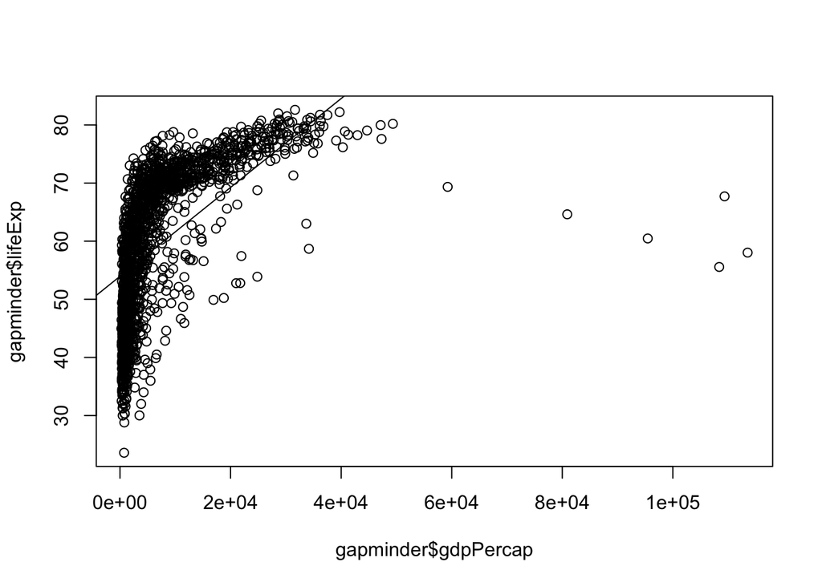

```r
plot(gapminder$gdpPercap, gapminder$lifeExp) #scatterplot (X then Y)
abline(lm(gapminder$lifeExp~gapminder$gdpPercap)) #add trend line (Y then X)
```

Notice how we always put the explanatory variable on the X axis(horizantal) and the outcome variable on the Y axis (vertical)

GDP per capita hard to read - change unit to thousands

```r
gapminder$gdpPercap <- gapminder$gdpPercap/1000
```

Make plot look a bit more professional

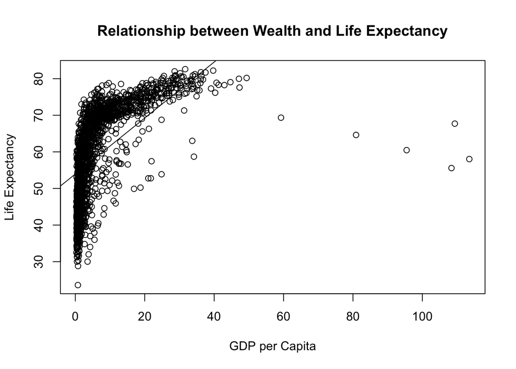

```r
plot(gapminder$gdpPercap, gapminder$lifeExp, main="Relationship between Wealth and Life Expectancy", xlab="GDP per Capita", ylab="Life Expectancy")
abline(lm(gapminder$lifeExp~gapminder$gdpPercap)) #and boom, you've already ran your 2nd regression
```

Does there appear to be a relationship in the sample?

What about with just Asia? There are multiple ways to do this:

We can create a new dataset ie a subset(I almost always choose this option)

```r
table(gapminder$continent)
```

```
##
##   Africa Americas     Asia   Europe  Oceania
##      624      300      396      360       24
```

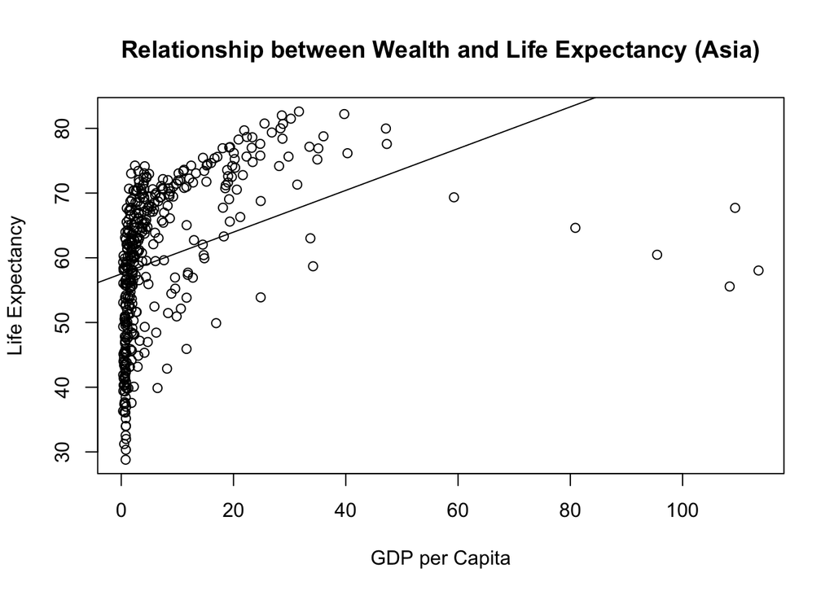

```r
asia <- gapminder[which(gapminder$continent=="Asia"),]
asia <- filter(gapminder, continent=="Asia") # This does the same thing using the dplyr package from tidyverse. I find it much more intuitive than "base R" so tend to use it more often.



plot(asia$gdpPercap, asia$lifeExp, main="Relationship between Wealth and Life Expectancy (Asia)", xlab="GDP per Capita", ylab="Life Expectancy")
abline(lm(asia$lifeExp~asia$gdpPercap)) #and boom, another regression
```

Exclude Europe

```r
noteuro <- gapminder[which(gapminder$continent!="Europe"),] # the != does not equal
noteuro <- filter(gapminder, continent!="Europe")
```

Exclude the super rich - use greater than or less than

```r
notrich <- gapminder[which(gapminder$gdpPercap< 50),] # less than 50,000 - this drops oil-rich outliers like Kuwait
notrich <- filter(gapminder, gdpPercap< 50)
```

Check in: Try creating a scatterplot with just the 1) Africa OR 2) country-years where life expectancy is less than 70.

#Looking at the data over time: Time to look at something a bit more fun. How has life expectancy changed across the world since the 1950s?

Mean life expectancy?

```r
mean(gapminder$lifeExp)
```

```
## [1] 59.47444
```

```r
min(gapminder$lifeExp)
```

```
## [1] 23.599
```

```r
max(gapminder$lifeExp)
```

```
## [1] 82.603
```

```r
range(gapminder$lifeExp)
```

```
## [1] 23.599 82.603
```

Create a histogram for life expectancy

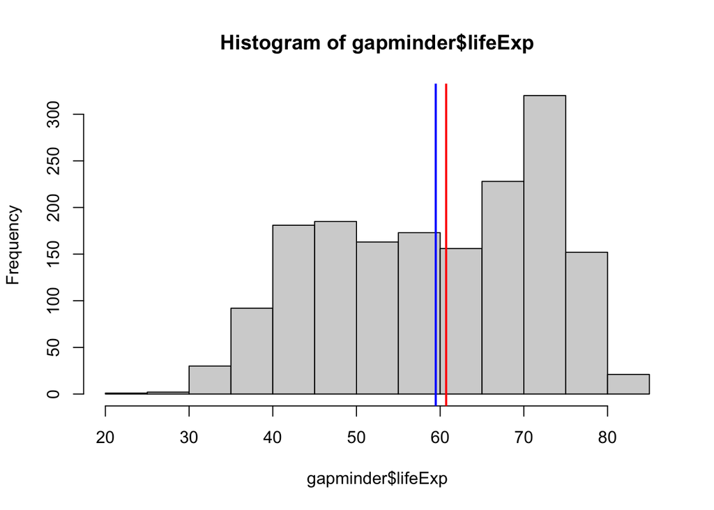

```r
hist(gapminder$lifeExp)
abline(v=mean(gapminder$lifeExp), col="blue", lwd=2)#adds a vertical(v) line for the mean
abline(v=median(gapminder$lifeExp), col="red", lwd=2)#a a line for mediant
```

abline gives us a line. v is for vertical

Density plots and boxplots show us similar information

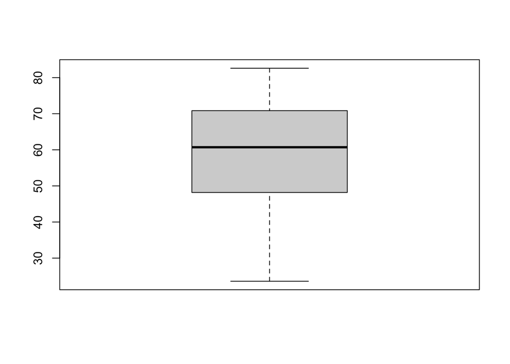

```r
boxplot(gapminder$lifeExp)
```

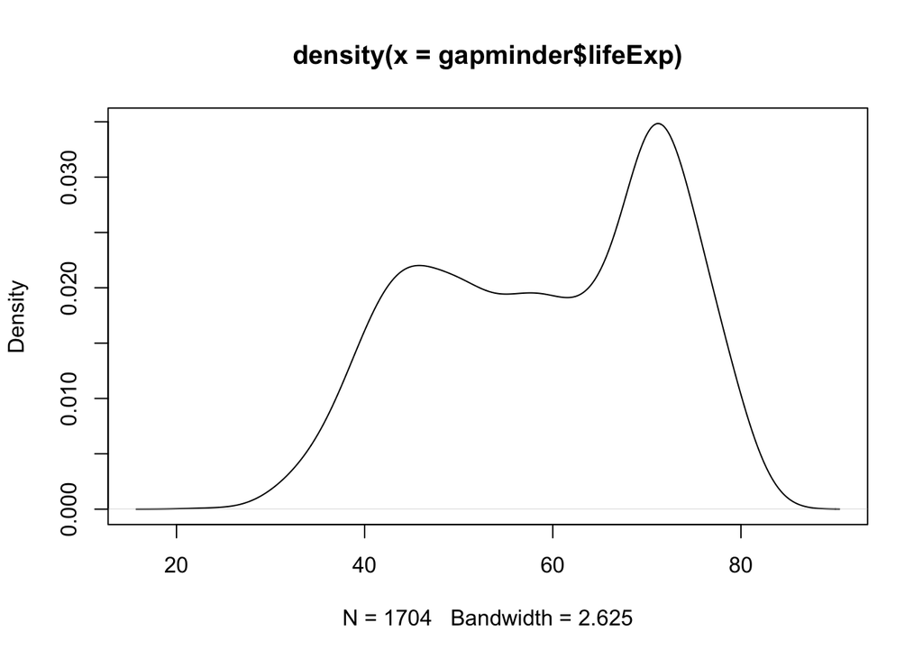

```r
plot(density(gapminder$lifeExp))
```

```r
#How can we find out which country-years are at the very bottom?
```

Check: How many observations are from Africa and how many are from Europe

```r
mean(gapminder$lifeExp[gapminder$continent=="Africa"]) #average for Africa
```

```
## [1] 48.86533
```

```r
mean(gapminder$lifeExp[gapminder$continent=="Europe"]) #average for Europe
```

```
## [1] 71.90369
```

```r
mean(asia$lifeExp)
```

```
## [1] 60.0649
```

```r
#find the mean for the Americas
```

Let’s make a simple scatterplot with year on the horizontal axis, and life expectancy on the vertical axis. A regression allows us to look at the relationship between variables linear regression model, and you’re looking at the effect of the IV on the DV

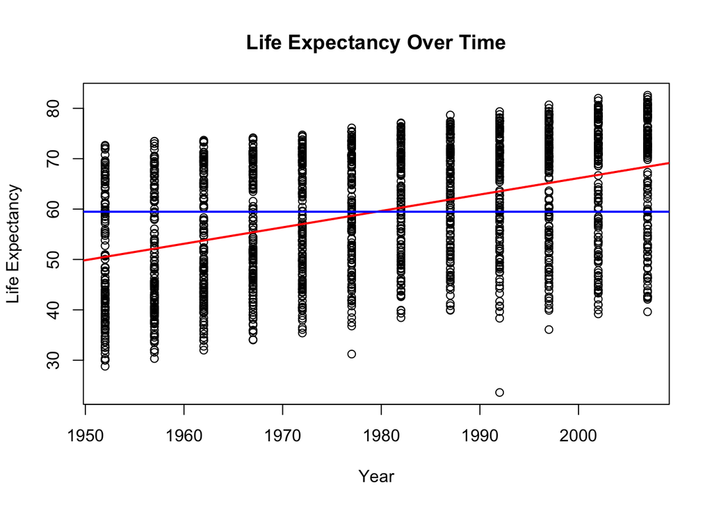

```r
plot(gapminder$year, gapminder$lifeExp, ylab = "Life Expectancy", xlab = "Year", main = "Life Expectancy Over Time")
abline(lm(gapminder$lifeExp ~ gapminder$year), col="red", lwd=2) # What type of relationship is this?
abline(h=mean(gapminder$lifeExp), col="blue", lwd=2)
```

That is a bit overwhelming lets just look at 2007 - ie lets create a subset

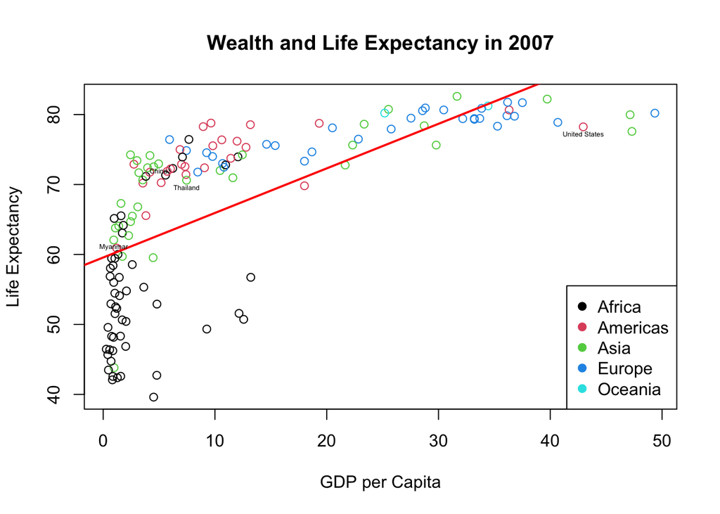

```r
g2007 <- gapminder[which(gapminder$year==2007),] #just using base R

#New Graph
plot(g2007$gdpPercap, g2007$lifeExp, ylab = "Life Expectancy", xlab = "GDP per Capita", main = "Wealth and Life Expectancy in 2007", col=factor(g2007$continent)) #color for continent
abline(lm(g2007$lifeExp ~ g2007$gdpPercap), col="red", lwd=2)
legend("bottomright", legend = levels(factor(g2007$continent)), pch=19, col = factor(levels(factor(g2007$continent))))

#I want to add labels for specific countries
g2007$stars <- ifelse(g2007$country=="United States"|g2007$country=="China" |g2007$country=="Myanmar" |g2007$country=="Thailand", as.character(g2007$country), "") #create a new variable for notable countries, all else will be empty.
text(g2007$gdpPercap, g2007$lifeExp-1, g2007$stars, cex=.4) #add text to location
```

Check: Can you create the same for 1952

A boxplot for each year can show us how the distribution has changed over time

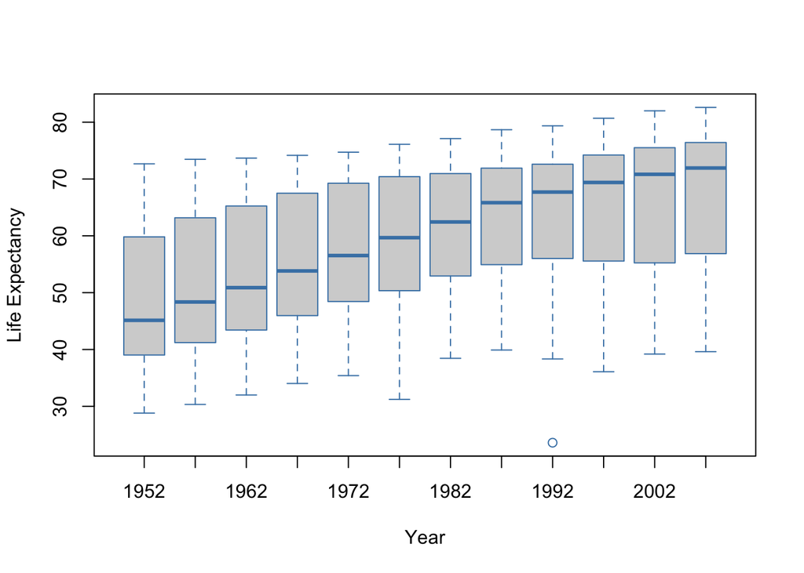

```r
boxplot(gapminder$lifeExp~gapminder$year, xlab = "Year", ylab="Life Expectancy", border = "steelblue")
```

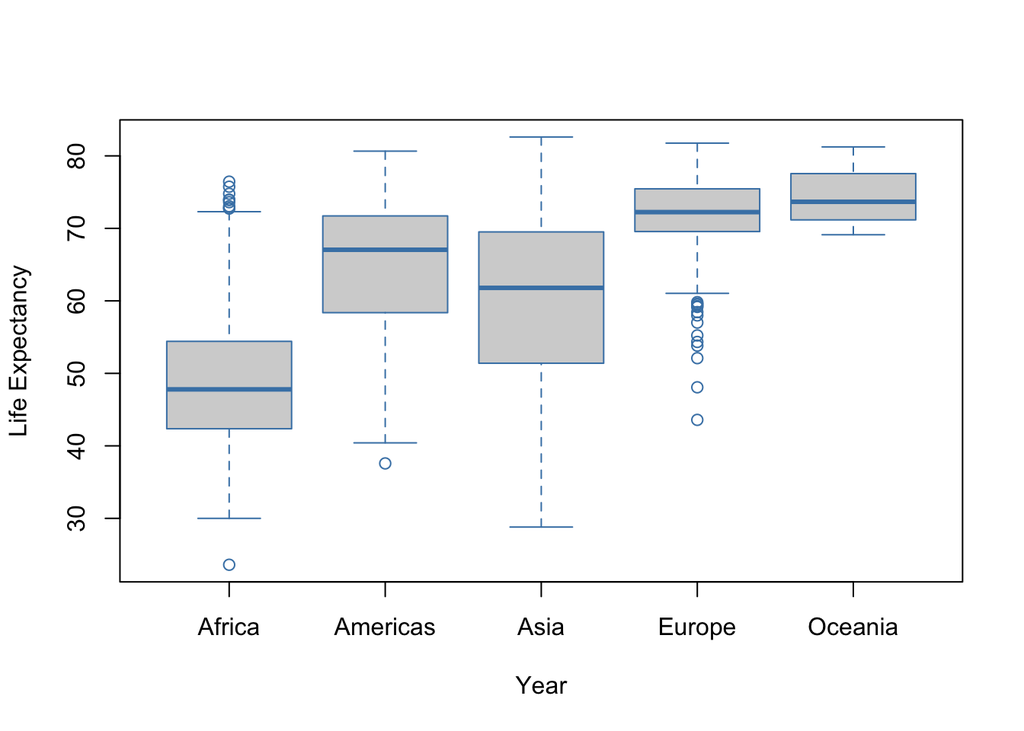

```r
boxplot(gapminder$lifeExp~gapminder$continent, xlab = "Year", ylab="Life Expectancy", border = "steelblue")
```

Lets look at changes in thailand over time

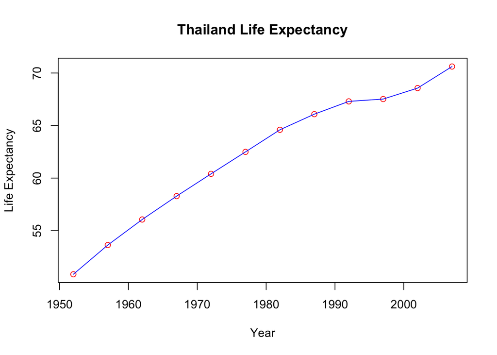

```r
thai <- filter(gapminder, country=="Thailand")
plot(thai$year, thai$lifeExp, xlab="Year", ylab="Life Expectancy", col="red", main="Thailand Life Expectancy")
lines(thai$year, thai$lifeExp, col="blue")
```

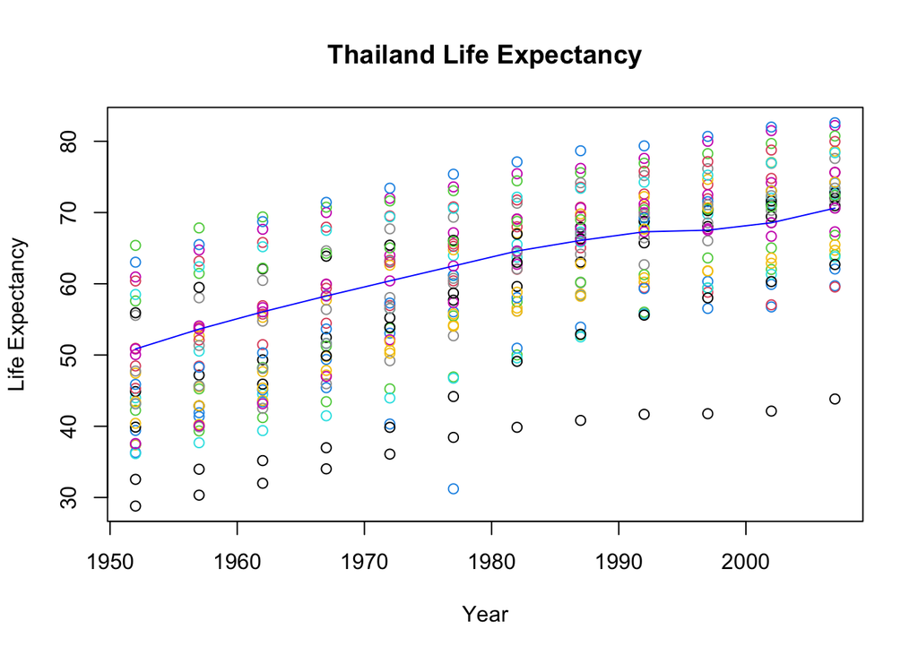

```r
plot(asia$year, asia$lifeExp, xlab="Year", ylab="Life Expectancy", col=gapminder$country, main="Thailand Life Expectancy")
lines(thai$year, thai$lifeExp, col="blue")
```

Check: Do the same above for a different country

I’ve clearly had too much fun. Your turn to make something interesting.